# Risk Factor Analysis

## Outcome Variable

**Outcome Variable:** ever_co

## Predictor Variables

**Intervention Variable:** mhtcm

**Adjustment Set:**

unadjusted

## Stratifying Variables

The analysis was stratified on these variable(s):

- agecat
- studyid
- country

## Data Summary

| agecat | studyid | country | mhtcm | ever_co | n_cell | n |
| --- | --- | --- | --- | --- | --- | --- |
| 0-24 months | COHORTS | GUATEMALA | >=155 cm | 0 | 150 | 1275 |
| 0-24 months | COHORTS | GUATEMALA | >=155 cm | 1 | 15 | 1275 |
| 0-24 months | COHORTS | GUATEMALA | <151 cm | 0 | 733 | 1275 |
| 0-24 months | COHORTS | GUATEMALA | <151 cm | 1 | 102 | 1275 |
| 0-24 months | COHORTS | GUATEMALA | [151-155) cm | 0 | 246 | 1275 |
| 0-24 months | COHORTS | GUATEMALA | [151-155) cm | 1 | 29 | 1275 |
| 0-24 months | COHORTS | INDIA | >=155 cm | 0 | 541 | 1905 |
| 0-24 months | COHORTS | INDIA | >=155 cm | 1 | 30 | 1905 |
| 0-24 months | COHORTS | INDIA | <151 cm | 0 | 737 | 1905 |
| 0-24 months | COHORTS | INDIA | <151 cm | 1 | 86 | 1905 |
| 0-24 months | COHORTS | INDIA | [151-155) cm | 0 | 481 | 1905 |
| 0-24 months | COHORTS | INDIA | [151-155) cm | 1 | 30 | 1905 |
| 0-24 months | COHORTS | PHILIPPINES | >=155 cm | 0 | 554 | 3045 |
| 0-24 months | COHORTS | PHILIPPINES | >=155 cm | 1 | 75 | 3045 |
| 0-24 months | COHORTS | PHILIPPINES | <151 cm | 0 | 1186 | 3045 |
| 0-24 months | COHORTS | PHILIPPINES | <151 cm | 1 | 354 | 3045 |
| 0-24 months | COHORTS | PHILIPPINES | [151-155) cm | 0 | 745 | 3045 |
| 0-24 months | COHORTS | PHILIPPINES | [151-155) cm | 1 | 131 | 3045 |
| 0-24 months | Guatemala BSC | GUATEMALA | >=155 cm | 0 | 35 | 235 |
| 0-24 months | Guatemala BSC | GUATEMALA | >=155 cm | 1 | 1 | 235 |
| 0-24 months | Guatemala BSC | GUATEMALA | <151 cm | 0 | 131 | 235 |
| 0-24 months | Guatemala BSC | GUATEMALA | <151 cm | 1 | 12 | 235 |
| 0-24 months | Guatemala BSC | GUATEMALA | [151-155) cm | 0 | 51 | 235 |
| 0-24 months | Guatemala BSC | GUATEMALA | [151-155) cm | 1 | 5 | 235 |
| 0-24 months | iLiNS-Zinc | BURKINA FASO | >=155 cm | 0 | 2575 | 3216 |
| 0-24 months | iLiNS-Zinc | BURKINA FASO | >=155 cm | 1 | 324 | 3216 |
| 0-24 months | iLiNS-Zinc | BURKINA FASO | <151 cm | 0 | 71 | 3216 |
| 0-24 months | iLiNS-Zinc | BURKINA FASO | <151 cm | 1 | 20 | 3216 |
| 0-24 months | iLiNS-Zinc | BURKINA FASO | [151-155) cm | 0 | 184 | 3216 |
| 0-24 months | iLiNS-Zinc | BURKINA FASO | [151-155) cm | 1 | 42 | 3216 |

[output cut: 378 more lines]

The following strata were considered:

- agecat: 0-24 months, studyid: COHORTS, country: GUATEMALA
- agecat: 0-24 months, studyid: COHORTS, country: INDIA
- agecat: 0-24 months, studyid: COHORTS, country: PHILIPPINES
- agecat: 0-24 months, studyid: Guatemala BSC, country: GUATEMALA
- agecat: 0-24 months, studyid: iLiNS-Zinc, country: BURKINA FASO
- agecat: 0-24 months, studyid: JiVitA-3, country: BANGLADESH
- agecat: 0-24 months, studyid: Keneba, country: GAMBIA
- agecat: 0-24 months, studyid: LCNI-5, country: MALAWI
- agecat: 0-24 months, studyid: MAL-ED, country: BANGLADESH
- agecat: 0-24 months, studyid: MAL-ED, country: BRAZIL
- agecat: 0-24 months, studyid: MAL-ED, country: INDIA
- agecat: 0-24 months, studyid: MAL-ED, country: NEPAL
- agecat: 0-24 months, studyid: MAL-ED, country: PERU
- agecat: 0-24 months, studyid: MAL-ED, country: SOUTH AFRICA
- agecat: 0-24 months, studyid: MAL-ED, country: TANZANIA, UNITED REPUBLIC OF
- agecat: 0-24 months, studyid: NIH-Birth, country: BANGLADESH
- agecat: 0-24 months, studyid: NIH-Crypto, country: BANGLADESH
- agecat: 0-24 months, studyid: PROBIT, country: BELARUS
- agecat: 0-24 months, studyid: PROVIDE, country: BANGLADESH
- agecat: 0-24 months, studyid: SAS-CompFeed, country: INDIA
- agecat: 0-24 months, studyid: SAS-FoodSuppl, country: INDIA
- agecat: 0-24 months, studyid: TanzaniaChild2, country: TANZANIA, UNITED REPUBLIC OF
- agecat: 0-24 months, studyid: ZVITAMBO, country: ZIMBABWE
- agecat: 0-6 months, studyid: COHORTS, country: GUATEMALA
- agecat: 0-6 months, studyid: COHORTS, country: INDIA
- agecat: 0-6 months, studyid: COHORTS, country: PHILIPPINES
- agecat: 0-6 months, studyid: Guatemala BSC, country: GUATEMALA
- agecat: 0-6 months, studyid: JiVitA-3, country: BANGLADESH
- agecat: 0-6 months, studyid: Keneba, country: GAMBIA
- agecat: 0-6 months, studyid: LCNI-5, country: MALAWI
- agecat: 0-6 months, studyid: MAL-ED, country: BANGLADESH
- agecat: 0-6 months, studyid: MAL-ED, country: BRAZIL
- agecat: 0-6 months, studyid: MAL-ED, country: INDIA
- agecat: 0-6 months, studyid: MAL-ED, country: NEPAL
- agecat: 0-6 months, studyid: MAL-ED, country: PERU
- agecat: 0-6 months, studyid: MAL-ED, country: SOUTH AFRICA
- agecat: 0-6 months, studyid: MAL-ED, country: TANZANIA, UNITED REPUBLIC OF
- agecat: 0-6 months, studyid: NIH-Birth, country: BANGLADESH
- agecat: 0-6 months, studyid: NIH-Crypto, country: BANGLADESH
- agecat: 0-6 months, studyid: PROBIT, country: BELARUS
- agecat: 0-6 months, studyid: PROVIDE, country: BANGLADESH
- agecat: 0-6 months, studyid: SAS-CompFeed, country: INDIA
- agecat: 0-6 months, studyid: SAS-FoodSuppl, country: INDIA
- agecat: 0-6 months, studyid: TanzaniaChild2, country: TANZANIA, UNITED REPUBLIC OF
- agecat: 0-6 months, studyid: ZVITAMBO, country: ZIMBABWE
- agecat: 6-24 months, studyid: COHORTS, country: GUATEMALA
- agecat: 6-24 months, studyid: COHORTS, country: INDIA
- agecat: 6-24 months, studyid: COHORTS, country: PHILIPPINES
- agecat: 6-24 months, studyid: Guatemala BSC, country: GUATEMALA
- agecat: 6-24 months, studyid: iLiNS-Zinc, country: BURKINA FASO
- agecat: 6-24 months, studyid: JiVitA-3, country: BANGLADESH
- agecat: 6-24 months, studyid: Keneba, country: GAMBIA
- agecat: 6-24 months, studyid: LCNI-5, country: MALAWI
- agecat: 6-24 months, studyid: MAL-ED, country: BANGLADESH
- agecat: 6-24 months, studyid: MAL-ED, country: BRAZIL
- agecat: 6-24 months, studyid: MAL-ED, country: INDIA
- agecat: 6-24 months, studyid: MAL-ED, country: NEPAL
- agecat: 6-24 months, studyid: MAL-ED, country: PERU
- agecat: 6-24 months, studyid: MAL-ED, country: SOUTH AFRICA
- agecat: 6-24 months, studyid: MAL-ED, country: TANZANIA, UNITED REPUBLIC OF
- agecat: 6-24 months, studyid: NIH-Birth, country: BANGLADESH
- agecat: 6-24 months, studyid: NIH-Crypto, country: BANGLADESH
- agecat: 6-24 months, studyid: PROBIT, country: BELARUS
- agecat: 6-24 months, studyid: PROVIDE, country: BANGLADESH
- agecat: 6-24 months, studyid: SAS-CompFeed, country: INDIA
- agecat: 6-24 months, studyid: SAS-FoodSuppl, country: INDIA
- agecat: 6-24 months, studyid: TanzaniaChild2, country: TANZANIA, UNITED REPUBLIC OF
- agecat: 6-24 months, studyid: ZVITAMBO, country: ZIMBABWE

### Dropped Strata

Some strata were dropped due to rare outcomes:

- agecat: 0-24 months, studyid: Guatemala BSC, country: GUATEMALA
- agecat: 0-24 months, studyid: MAL-ED, country: BANGLADESH
- agecat: 0-24 months, studyid: MAL-ED, country: BRAZIL
- agecat: 0-24 months, studyid: MAL-ED, country: NEPAL
- agecat: 0-24 months, studyid: MAL-ED, country: PERU
- agecat: 0-24 months, studyid: MAL-ED, country: SOUTH AFRICA
- agecat: 0-24 months, studyid: PROBIT, country: BELARUS
- agecat: 0-6 months, studyid: COHORTS, country: GUATEMALA
- agecat: 0-6 months, studyid: Guatemala BSC, country: GUATEMALA
- agecat: 0-6 months, studyid: LCNI-5, country: MALAWI
- agecat: 0-6 months, studyid: MAL-ED, country: BANGLADESH
- agecat: 0-6 months, studyid: MAL-ED, country: BRAZIL
- agecat: 0-6 months, studyid: MAL-ED, country: INDIA
- agecat: 0-6 months, studyid: MAL-ED, country: NEPAL
- agecat: 0-6 months, studyid: MAL-ED, country: PERU
- agecat: 0-6 months, studyid: MAL-ED, country: SOUTH AFRICA
- agecat: 0-6 months, studyid: MAL-ED, country: TANZANIA, UNITED REPUBLIC OF
- agecat: 0-6 months, studyid: NIH-Crypto, country: BANGLADESH
- agecat: 0-6 months, studyid: PROBIT, country: BELARUS
- agecat: 0-6 months, studyid: SAS-FoodSuppl, country: INDIA
- agecat: 0-6 months, studyid: TanzaniaChild2, country: TANZANIA, UNITED REPUBLIC OF
- agecat: 6-24 months, studyid: Guatemala BSC, country: GUATEMALA
- agecat: 6-24 months, studyid: MAL-ED, country: BANGLADESH
- agecat: 6-24 months, studyid: MAL-ED, country: BRAZIL
- agecat: 6-24 months, studyid: MAL-ED, country: NEPAL
- agecat: 6-24 months, studyid: MAL-ED, country: PERU
- agecat: 6-24 months, studyid: MAL-ED, country: SOUTH AFRICA
- agecat: 6-24 months, studyid: PROBIT, country: BELARUS

## Methods Detail

We’re interested in the causal parameters $E[Y_a]$ for all values of $a \in \mathcal{A}$. These parameters represent the mean outcome if, possibly contrary to fact, we intervened to set all units to have $A=a$. Under the randomization and positivity assumptions, these are identified by the statistical parameters $\psi_a=E_W[E_{Y|A,W}(Y|A=a,W)]$. In addition, we’re interested in the mean of $Y$, $E[Y]$ under no intervention (the observed mean). We will estimate these parameters by using SuperLearner to fit the relevant likelihood factors – $E_{Y|A,W}(Y|A=a,W)$ and $p(A=a|W)$, and then updating our likelihood fit using a joint TMLE.

For unadjusted analyses ($W=\{\}$), initial likelihoods were estimated using Lrnr_glm to estimate the simple $E(Y|A)$ and Lrnr_mean to estimate $p(A)$. For adjusted analyses, a small library containing Lrnr_glmnet, Lrnr_xgboost, and Lrnr_mean was used.

Having estimated these parameters, we will then use the delta method to estimate relative risks and attributable risks relative to a prespecified baseline level of $A$.

# Results Detail

## Results Plots

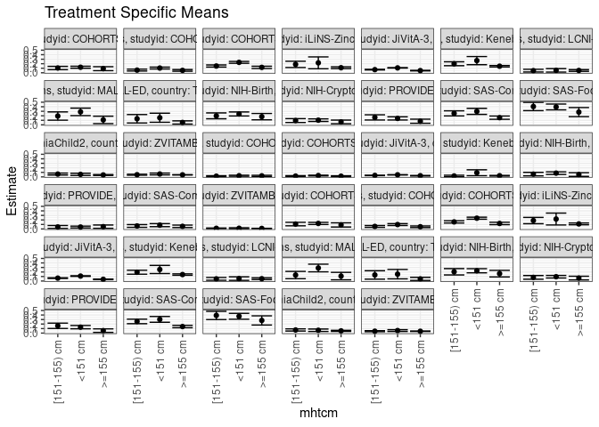

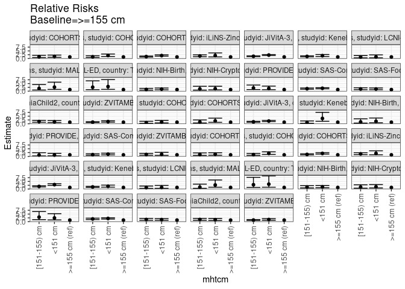

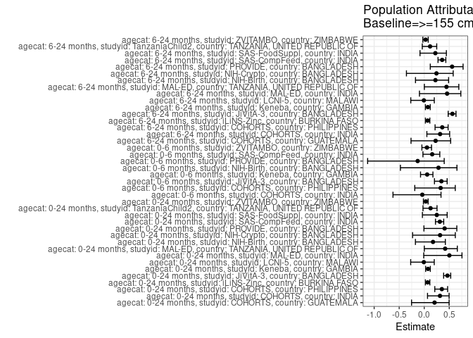

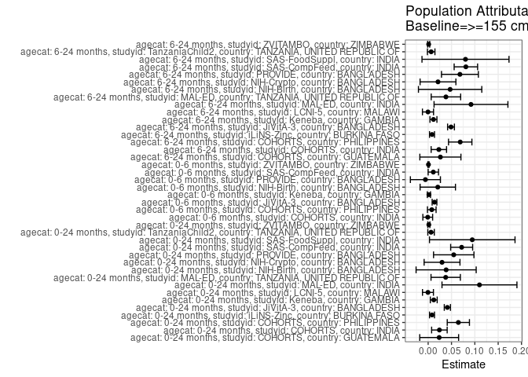

## Results Table

### Parameter: TSM

| agecat | studyid | country | intervention_level | baseline_level | estimate | ci_lower | ci_upper |
| --- | --- | --- | --- | --- | --- | --- | --- |
| 0-24 months | COHORTS | GUATEMALA | >=155 cm | NA | 0.0909091 | 0.0470274 | 0.1347908 |
| 0-24 months | COHORTS | GUATEMALA | <151 cm | NA | 0.1221557 | 0.0999359 | 0.1443755 |
| 0-24 months | COHORTS | GUATEMALA | [151-155) cm | NA | 0.1054545 | 0.0691396 | 0.1417695 |
| 0-24 months | COHORTS | INDIA | >=155 cm | NA | 0.0525394 | 0.0342345 | 0.0708443 |
| 0-24 months | COHORTS | INDIA | <151 cm | NA | 0.1044957 | 0.0835910 | 0.1254005 |
| 0-24 months | COHORTS | INDIA | [151-155) cm | NA | 0.0587084 | 0.0383209 | 0.0790959 |
| 0-24 months | COHORTS | PHILIPPINES | >=155 cm | NA | 0.1192369 | 0.0939072 | 0.1445665 |
| 0-24 months | COHORTS | PHILIPPINES | <151 cm | NA | 0.2298701 | 0.2088526 | 0.2508877 |
| 0-24 months | COHORTS | PHILIPPINES | [151-155) cm | NA | 0.1495434 | 0.1259235 | 0.1731632 |
| 0-24 months | iLiNS-Zinc | BURKINA FASO | >=155 cm | NA | 0.1117627 | 0.0918558 | 0.1316695 |
| 0-24 months | iLiNS-Zinc | BURKINA FASO | <151 cm | NA | 0.2197802 | 0.0883501 | 0.3512103 |
| 0-24 months | iLiNS-Zinc | BURKINA FASO | [151-155) cm | NA | 0.1858407 | 0.1163072 | 0.2553742 |
| 0-24 months | JiVitA-3 | BANGLADESH | >=155 cm | NA | 0.0477576 | 0.0412533 | 0.0542619 |
| 0-24 months | JiVitA-3 | BANGLADESH | <151 cm | NA | 0.1080418 | 0.1026335 | 0.1134500 |
| 0-24 months | JiVitA-3 | BANGLADESH | [151-155) cm | NA | 0.0692500 | 0.0627932 | 0.0757069 |
| 0-24 months | Keneba | GAMBIA | >=155 cm | NA | 0.1452736 | 0.1298656 | 0.1606816 |
| 0-24 months | Keneba | GAMBIA | <151 cm | NA | 0.2688172 | 0.1786938 | 0.3589406 |
| 0-24 months | Keneba | GAMBIA | [151-155) cm | NA | 0.1993865 | 0.1560067 | 0.2427664 |
| 0-24 months | LCNI-5 | MALAWI | >=155 cm | NA | 0.0505837 | 0.0316271 | 0.0695402 |
| 0-24 months | LCNI-5 | MALAWI | <151 cm | NA | 0.0534351 | 0.0148996 | 0.0919706 |
| 0-24 months | LCNI-5 | MALAWI | [151-155) cm | NA | 0.0468750 | 0.0169591 | 0.0767909 |
| 0-24 months | MAL-ED | INDIA | >=155 cm | NA | 0.1090909 | 0.0265295 | 0.1916523 |
| 0-24 months | MAL-ED | INDIA | <151 cm | NA | 0.2869565 | 0.2041119 | 0.3698012 |
| 0-24 months | MAL-ED | INDIA | [151-155) cm | NA | 0.1944444 | 0.1028379 | 0.2860510 |
| 0-24 months | MAL-ED | TANZANIA, UNITED REPUBLIC OF | >=155 cm | NA | 0.0522876 | 0.0169457 | 0.0876295 |
| 0-24 months | MAL-ED | TANZANIA, UNITED REPUBLIC OF | <151 cm | NA | 0.1568627 | 0.0568577 | 0.2568678 |
| 0-24 months | MAL-ED | TANZANIA, UNITED REPUBLIC OF | [151-155) cm | NA | 0.1346154 | 0.0416656 | 0.2275651 |
| 0-24 months | NIH-Birth | BANGLADESH | >=155 cm | NA | 0.1810345 | 0.1109082 | 0.2511608 |
| 0-24 months | NIH-Birth | BANGLADESH | <151 cm | NA | 0.2403315 | 0.1962801 | 0.2843829 |
| 0-24 months | NIH-Birth | BANGLADESH | [151-155) cm | NA | 0.1986301 | 0.1338624 | 0.2633979 |

[output cut: 90 more lines]

### Parameter: E(Y)

| agecat | studyid | country | intervention_level | baseline_level | estimate | ci_lower | ci_upper |
| --- | --- | --- | --- | --- | --- | --- | --- |
| 0-24 months | COHORTS | GUATEMALA | NA | NA | 0.1145098 | 0.0970244 | 0.1319952 |
| 0-24 months | COHORTS | INDIA | NA | NA | 0.0766404 | 0.0646915 | 0.0885893 |
| 0-24 months | COHORTS | PHILIPPINES | NA | NA | 0.1839080 | 0.1701456 | 0.1976705 |
| 0-24 months | iLiNS-Zinc | BURKINA FASO | NA | NA | 0.1200249 | 0.0999720 | 0.1400777 |
| 0-24 months | JiVitA-3 | BANGLADESH | NA | NA | 0.0889419 | 0.0850166 | 0.0928673 |
| 0-24 months | Keneba | GAMBIA | NA | NA | 0.1572664 | 0.1427858 | 0.1717470 |
| 0-24 months | LCNI-5 | MALAWI | NA | NA | 0.0501792 | 0.0353804 | 0.0649781 |
| 0-24 months | MAL-ED | INDIA | NA | NA | 0.2190083 | 0.1667935 | 0.2712230 |
| 0-24 months | MAL-ED | TANZANIA, UNITED REPUBLIC OF | NA | NA | 0.0898438 | 0.0547459 | 0.1249416 |
| 0-24 months | NIH-Birth | BANGLADESH | NA | NA | 0.2195513 | 0.1870467 | 0.2520558 |
| 0-24 months | NIH-Crypto | BANGLADESH | NA | NA | 0.0940397 | 0.0732057 | 0.1148737 |
| 0-24 months | PROVIDE | BANGLADESH | NA | NA | 0.1345291 | 0.1086533 | 0.1604050 |
| 0-24 months | SAS-CompFeed | INDIA | NA | NA | 0.2302158 | 0.1856981 | 0.2747335 |
| 0-24 months | SAS-FoodSuppl | INDIA | NA | NA | 0.3765281 | 0.3295143 | 0.4235419 |
| 0-24 months | TanzaniaChild2 | TANZANIA, UNITED REPUBLIC OF | NA | NA | 0.0491734 | 0.0404458 | 0.0579009 |
| 0-24 months | ZVITAMBO | ZIMBABWE | NA | NA | 0.0469068 | 0.0427263 | 0.0510872 |
| 0-6 months | COHORTS | INDIA | NA | NA | 0.0225443 | 0.0158017 | 0.0292868 |
| 0-6 months | COHORTS | PHILIPPINES | NA | NA | 0.0236531 | 0.0182537 | 0.0290525 |
| 0-6 months | JiVitA-3 | BANGLADESH | NA | NA | 0.0396299 | 0.0371163 | 0.0421435 |
| 0-6 months | Keneba | GAMBIA | NA | NA | 0.0278293 | 0.0208847 | 0.0347739 |
| 0-6 months | NIH-Birth | BANGLADESH | NA | NA | 0.0723473 | 0.0519719 | 0.0927227 |
| 0-6 months | PROVIDE | BANGLADESH | NA | NA | 0.0448430 | 0.0291486 | 0.0605375 |
| 0-6 months | SAS-CompFeed | INDIA | NA | NA | 0.0694645 | 0.0441638 | 0.0947653 |
| 0-6 months | ZVITAMBO | ZIMBABWE | NA | NA | 0.0123621 | 0.0101730 | 0.0145512 |
| 6-24 months | COHORTS | GUATEMALA | NA | NA | 0.1152513 | 0.0968196 | 0.1336830 |
| 6-24 months | COHORTS | INDIA | NA | NA | 0.0721649 | 0.0603481 | 0.0839818 |
| 6-24 months | COHORTS | PHILIPPINES | NA | NA | 0.1908832 | 0.1763448 | 0.2054216 |
| 6-24 months | iLiNS-Zinc | BURKINA FASO | NA | NA | 0.1200249 | 0.0999720 | 0.1400777 |
| 6-24 months | JiVitA-3 | BANGLADESH | NA | NA | 0.0868884 | 0.0822172 | 0.0915596 |
| 6-24 months | Keneba | GAMBIA | NA | NA | 0.1544750 | 0.1397785 | 0.1691716 |
| 6-24 months | LCNI-5 | MALAWI | NA | NA | 0.0510328 | 0.0359888 | 0.0660768 |
| 6-24 months | MAL-ED | INDIA | NA | NA | 0.2008547 | 0.1494120 | 0.2522974 |
| 6-24 months | MAL-ED | TANZANIA, UNITED REPUBLIC OF | NA | NA | 0.0857143 | 0.0505889 | 0.1208396 |
| 6-24 months | NIH-Birth | BANGLADESH | NA | NA | 0.2103321 | 0.1759902 | 0.2446740 |
| 6-24 months | NIH-Crypto | BANGLADESH | NA | NA | 0.0863014 | 0.0659171 | 0.1066856 |
| 6-24 months | PROVIDE | BANGLADESH | NA | NA | 0.1223491 | 0.0963874 | 0.1483108 |
| 6-24 months | SAS-CompFeed | INDIA | NA | NA | 0.2255286 | 0.1871466 | 0.2639106 |
| 6-24 months | SAS-FoodSuppl | INDIA | NA | NA | 0.3600000 | 0.3129020 | 0.4070980 |
| 6-24 months | TanzaniaChild2 | TANZANIA, UNITED REPUBLIC OF | NA | NA | 0.0554435 | 0.0453713 | 0.0655158 |
| 6-24 months | ZVITAMBO | ZIMBABWE | NA | NA | 0.0416377 | 0.0374209 | 0.0458544 |

### Parameter: RR

| agecat | studyid | country | intervention_level | baseline_level | estimate | ci_lower | ci_upper |
| --- | --- | --- | --- | --- | --- | --- | --- |
| 0-24 months | COHORTS | GUATEMALA | >=155 cm | >=155 cm | 1.0000000 | 1.0000000 | 1.000000 |
| 0-24 months | COHORTS | GUATEMALA | <151 cm | >=155 cm | 1.3437126 | 0.8021994 | 2.250767 |
| 0-24 months | COHORTS | GUATEMALA | [151-155) cm | >=155 cm | 1.1600000 | 0.6411272 | 2.098803 |
| 0-24 months | COHORTS | INDIA | >=155 cm | >=155 cm | 1.0000000 | 1.0000000 | 1.000000 |
| 0-24 months | COHORTS | INDIA | <151 cm | >=155 cm | 1.9889024 | 1.3308648 | 2.972303 |
| 0-24 months | COHORTS | INDIA | [151-155) cm | >=155 cm | 1.1174168 | 0.6832502 | 1.827472 |
| 0-24 months | COHORTS | PHILIPPINES | >=155 cm | >=155 cm | 1.0000000 | 1.0000000 | 1.000000 |
| 0-24 months | COHORTS | PHILIPPINES | <151 cm | >=155 cm | 1.9278442 | 1.5297893 | 2.429474 |
| 0-24 months | COHORTS | PHILIPPINES | [151-155) cm | >=155 cm | 1.2541705 | 0.9624812 | 1.634259 |
| 0-24 months | iLiNS-Zinc | BURKINA FASO | >=155 cm | >=155 cm | 1.0000000 | 1.0000000 | 1.000000 |
| 0-24 months | iLiNS-Zinc | BURKINA FASO | <151 cm | >=155 cm | 1.9664903 | 1.0535387 | 3.670567 |
| 0-24 months | iLiNS-Zinc | BURKINA FASO | [151-155) cm | >=155 cm | 1.6628155 | 1.1528975 | 2.398266 |
| 0-24 months | JiVitA-3 | BANGLADESH | >=155 cm | >=155 cm | 1.0000000 | 1.0000000 | 1.000000 |
| 0-24 months | JiVitA-3 | BANGLADESH | <151 cm | >=155 cm | 2.2622962 | 1.9589303 | 2.612642 |
| 0-24 months | JiVitA-3 | BANGLADESH | [151-155) cm | >=155 cm | 1.4500325 | 1.2267775 | 1.713917 |
| 0-24 months | Keneba | GAMBIA | >=155 cm | >=155 cm | 1.0000000 | 1.0000000 | 1.000000 |
| 0-24 months | Keneba | GAMBIA | <151 cm | >=155 cm | 1.8504198 | 1.3018375 | 2.630170 |
| 0-24 months | Keneba | GAMBIA | [151-155) cm | >=155 cm | 1.3724893 | 1.0774358 | 1.748342 |
| 0-24 months | LCNI-5 | MALAWI | >=155 cm | >=155 cm | 1.0000000 | 1.0000000 | 1.000000 |
| 0-24 months | LCNI-5 | MALAWI | <151 cm | >=155 cm | 1.0563711 | 0.4686570 | 2.381101 |
| 0-24 months | LCNI-5 | MALAWI | [151-155) cm | >=155 cm | 0.9266827 | 0.4420883 | 1.942465 |
| 0-24 months | MAL-ED | INDIA | >=155 cm | >=155 cm | 1.0000000 | 1.0000000 | 1.000000 |
| 0-24 months | MAL-ED | INDIA | <151 cm | >=155 cm | 2.6304348 | 1.1701604 | 5.913025 |
| 0-24 months | MAL-ED | INDIA | [151-155) cm | >=155 cm | 1.7824074 | 0.7308807 | 4.346778 |
| 0-24 months | MAL-ED | TANZANIA, UNITED REPUBLIC OF | >=155 cm | >=155 cm | 1.0000000 | 1.0000000 | 1.000000 |
| 0-24 months | MAL-ED | TANZANIA, UNITED REPUBLIC OF | <151 cm | >=155 cm | 3.0000000 | 1.1846760 | 7.597014 |
| 0-24 months | MAL-ED | TANZANIA, UNITED REPUBLIC OF | [151-155) cm | >=155 cm | 2.5745192 | 0.9796292 | 6.765978 |
| 0-24 months | NIH-Birth | BANGLADESH | >=155 cm | >=155 cm | 1.0000000 | 1.0000000 | 1.000000 |
| 0-24 months | NIH-Birth | BANGLADESH | <151 cm | >=155 cm | 1.3275454 | 0.8648408 | 2.037805 |
| 0-24 months | NIH-Birth | BANGLADESH | [151-155) cm | >=155 cm | 1.0971950 | 0.6612806 | 1.820463 |

[output cut: 90 more lines]

### Parameter: PAR

| agecat | studyid | country | intervention_level | baseline_level | estimate | ci_lower | ci_upper |
| --- | --- | --- | --- | --- | --- | --- | --- |
| 0-24 months | COHORTS | GUATEMALA | >=155 cm | NA | 0.0236007 | -0.0180281 | 0.0652295 |
| 0-24 months | COHORTS | INDIA | >=155 cm | NA | 0.0241010 | 0.0074583 | 0.0407437 |
| 0-24 months | COHORTS | PHILIPPINES | >=155 cm | NA | 0.0646712 | 0.0408819 | 0.0884605 |
| 0-24 months | iLiNS-Zinc | BURKINA FASO | >=155 cm | NA | 0.0082622 | 0.0029331 | 0.0135913 |
| 0-24 months | JiVitA-3 | BANGLADESH | >=155 cm | NA | 0.0411844 | 0.0345574 | 0.0478113 |
| 0-24 months | Keneba | GAMBIA | >=155 cm | NA | 0.0119927 | 0.0046316 | 0.0193539 |
| 0-24 months | LCNI-5 | MALAWI | >=155 cm | NA | -0.0004044 | -0.0121093 | 0.0113004 |
| 0-24 months | MAL-ED | INDIA | >=155 cm | NA | 0.1099174 | 0.0296403 | 0.1901944 |
| 0-24 months | MAL-ED | TANZANIA, UNITED REPUBLIC OF | >=155 cm | NA | 0.0375562 | 0.0061253 | 0.0689871 |
| 0-24 months | NIH-Birth | BANGLADESH | >=155 cm | NA | 0.0385168 | -0.0258716 | 0.1029052 |
| 0-24 months | NIH-Crypto | BANGLADESH | >=155 cm | NA | 0.0297540 | -0.0086368 | 0.0681448 |
| 0-24 months | PROVIDE | BANGLADESH | >=155 cm | NA | 0.0548190 | 0.0115649 | 0.0980731 |
| 0-24 months | SAS-CompFeed | INDIA | >=155 cm | NA | 0.0717651 | 0.0482096 | 0.0953207 |
| 0-24 months | SAS-FoodSuppl | INDIA | >=155 cm | NA | 0.0944768 | 0.0028554 | 0.1860983 |
| 0-24 months | TanzaniaChild2 | TANZANIA, UNITED REPUBLIC OF | >=155 cm | NA | 0.0062204 | -0.0007265 | 0.0131672 |
| 0-24 months | ZVITAMBO | ZIMBABWE | >=155 cm | NA | 0.0014930 | -0.0007182 | 0.0037041 |
| 0-6 months | COHORTS | INDIA | >=155 cm | NA | -0.0008791 | -0.0113429 | 0.0095847 |
| 0-6 months | COHORTS | PHILIPPINES | >=155 cm | NA | 0.0077548 | -0.0014774 | 0.0169871 |
| 0-6 months | JiVitA-3 | BANGLADESH | >=155 cm | NA | 0.0136022 | 0.0085518 | 0.0186526 |
| 0-6 months | Keneba | GAMBIA | >=155 cm | NA | 0.0016163 | -0.0018388 | 0.0050713 |
| 0-6 months | NIH-Birth | BANGLADESH | >=155 cm | NA | 0.0206231 | -0.0172615 | 0.0585078 |
| 0-6 months | PROVIDE | BANGLADESH | >=155 cm | NA | -0.0058816 | -0.0380513 | 0.0262881 |
| 0-6 months | SAS-CompFeed | INDIA | >=155 cm | NA | 0.0110575 | -0.0000322 | 0.0221471 |
| 0-6 months | ZVITAMBO | ZIMBABWE | >=155 cm | NA | 0.0006729 | -0.0005206 | 0.0018664 |
| 6-24 months | COHORTS | GUATEMALA | >=155 cm | NA | 0.0262102 | -0.0177816 | 0.0702020 |
| 6-24 months | COHORTS | INDIA | >=155 cm | NA | 0.0228949 | 0.0063782 | 0.0394116 |
| 6-24 months | COHORTS | PHILIPPINES | >=155 cm | NA | 0.0686801 | 0.0436349 | 0.0937252 |
| 6-24 months | iLiNS-Zinc | BURKINA FASO | >=155 cm | NA | 0.0082622 | 0.0029331 | 0.0135913 |
| 6-24 months | JiVitA-3 | BANGLADESH | >=155 cm | NA | 0.0489510 | 0.0416656 | 0.0562364 |
| 6-24 months | Keneba | GAMBIA | >=155 cm | NA | 0.0113204 | 0.0038571 | 0.0187838 |
| 6-24 months | LCNI-5 | MALAWI | >=155 cm | NA | -0.0003506 | -0.0122349 | 0.0115337 |
| 6-24 months | MAL-ED | INDIA | >=155 cm | NA | 0.0917638 | 0.0126502 | 0.1708774 |
| 6-24 months | MAL-ED | TANZANIA, UNITED REPUBLIC OF | >=155 cm | NA | 0.0380952 | 0.0065391 | 0.0696514 |
| 6-24 months | NIH-Birth | BANGLADESH | >=155 cm | NA | 0.0470668 | -0.0207869 | 0.1149205 |
| 6-24 months | NIH-Crypto | BANGLADESH | >=155 cm | NA | 0.0210840 | -0.0172877 | 0.0594556 |
| 6-24 months | PROVIDE | BANGLADESH | >=155 cm | NA | 0.0680855 | 0.0285827 | 0.1075884 |
| 6-24 months | SAS-CompFeed | INDIA | >=155 cm | NA | 0.0808162 | 0.0556972 | 0.1059351 |
| 6-24 months | SAS-FoodSuppl | INDIA | >=155 cm | NA | 0.0800000 | -0.0132097 | 0.1732097 |
| 6-24 months | TanzaniaChild2 | TANZANIA, UNITED REPUBLIC OF | >=155 cm | NA | 0.0064869 | -0.0015553 | 0.0145291 |
| 6-24 months | ZVITAMBO | ZIMBABWE | >=155 cm | NA | 0.0011465 | -0.0010842 | 0.0033772 |

### Parameter: PAF

| agecat | studyid | country | intervention_level | baseline_level | estimate | ci_lower | ci_upper |
| --- | --- | --- | --- | --- | --- | --- | --- |
| 0-24 months | COHORTS | GUATEMALA | >=155 cm | NA | 0.2061021 | -0.2532630 | 0.4970937 |
| 0-24 months | COHORTS | INDIA | >=155 cm | NA | 0.3144687 | 0.0657696 | 0.4969623 |
| 0-24 months | COHORTS | PHILIPPINES | >=155 cm | NA | 0.3516494 | 0.2108150 | 0.4673512 |
| 0-24 months | iLiNS-Zinc | BURKINA FASO | >=155 cm | NA | 0.0688374 | 0.0237332 | 0.1118578 |
| 0-24 months | JiVitA-3 | BANGLADESH | >=155 cm | NA | 0.4630478 | 0.3876882 | 0.5291326 |
| 0-24 months | Keneba | GAMBIA | >=155 cm | NA | 0.0762575 | 0.0286088 | 0.1215688 |
| 0-24 months | LCNI-5 | MALAWI | >=155 cm | NA | -0.0080600 | -0.2705026 | 0.2001709 |
| 0-24 months | MAL-ED | INDIA | >=155 cm | NA | 0.5018868 | -0.0101766 | 0.7543828 |
| 0-24 months | MAL-ED | TANZANIA, UNITED REPUBLIC OF | >=155 cm | NA | 0.4180165 | 0.0012619 | 0.6608672 |
| 0-24 months | NIH-Birth | BANGLADESH | >=155 cm | NA | 0.1754342 | -0.1758867 | 0.4217906 |
| 0-24 months | NIH-Crypto | BANGLADESH | >=155 cm | NA | 0.3163984 | -0.2327008 | 0.6209046 |
| 0-24 months | PROVIDE | BANGLADESH | >=155 cm | NA | 0.4074879 | -0.0059589 | 0.6510090 |
| 0-24 months | SAS-CompFeed | INDIA | >=155 cm | NA | 0.3117298 | 0.2244057 | 0.3892220 |
| 0-24 months | SAS-FoodSuppl | INDIA | >=155 cm | NA | 0.2509158 | -0.0363236 | 0.4585405 |
| 0-24 months | TanzaniaChild2 | TANZANIA, UNITED REPUBLIC OF | >=155 cm | NA | 0.1264985 | -0.0249221 | 0.2555484 |
| 0-24 months | ZVITAMBO | ZIMBABWE | >=155 cm | NA | 0.0318281 | -0.0163973 | 0.0777654 |
| 0-6 months | COHORTS | INDIA | >=155 cm | NA | -0.0389961 | -0.6239218 | 0.3352433 |
| 0-6 months | COHORTS | PHILIPPINES | >=155 cm | NA | 0.3278573 | -0.1888681 | 0.6199950 |
| 0-6 months | JiVitA-3 | BANGLADESH | >=155 cm | NA | 0.3432303 | 0.2044735 | 0.4577850 |
| 0-6 months | Keneba | GAMBIA | >=155 cm | NA | 0.0580777 | -0.0737124 | 0.1736916 |
| 0-6 months | NIH-Birth | BANGLADESH | >=155 cm | NA | 0.2850575 | -0.4757933 | 0.6536488 |
| 0-6 months | PROVIDE | BANGLADESH | >=155 cm | NA | -0.1311594 | -1.1303471 | 0.3993835 |
| 0-6 months | SAS-CompFeed | INDIA | >=155 cm | NA | 0.1591814 | -0.0259680 | 0.3109182 |
| 0-6 months | ZVITAMBO | ZIMBABWE | >=155 cm | NA | 0.0544350 | -0.0466895 | 0.1457896 |
| 6-24 months | COHORTS | GUATEMALA | >=155 cm | NA | 0.2274179 | -0.2639609 | 0.5277677 |
| 6-24 months | COHORTS | INDIA | >=155 cm | NA | 0.3172576 | 0.0527751 | 0.5078917 |
| 6-24 months | COHORTS | PHILIPPINES | >=155 cm | NA | 0.3598017 | 0.2166489 | 0.4767941 |
| 6-24 months | iLiNS-Zinc | BURKINA FASO | >=155 cm | NA | 0.0688374 | 0.0237332 | 0.1118578 |
| 6-24 months | JiVitA-3 | BANGLADESH | >=155 cm | NA | 0.5633780 | 0.4784773 | 0.6344573 |
| 6-24 months | Keneba | GAMBIA | >=155 cm | NA | 0.0732833 | 0.0240390 | 0.1200428 |
| 6-24 months | LCNI-5 | MALAWI | >=155 cm | NA | -0.0068699 | -0.2688686 | 0.2010307 |
| 6-24 months | MAL-ED | INDIA | >=155 cm | NA | 0.4568665 | -0.0954428 | 0.7307080 |
| 6-24 months | MAL-ED | TANZANIA, UNITED REPUBLIC OF | >=155 cm | NA | 0.4444444 | 0.0022396 | 0.6906652 |
| 6-24 months | NIH-Birth | BANGLADESH | >=155 cm | NA | 0.2237737 | -0.1743640 | 0.4869332 |
| 6-24 months | NIH-Crypto | BANGLADESH | >=155 cm | NA | 0.2443064 | -0.3552454 | 0.5786204 |
| 6-24 months | PROVIDE | BANGLADESH | >=155 cm | NA | 0.5564858 | 0.1210607 | 0.7762020 |
| 6-24 months | SAS-CompFeed | INDIA | >=155 cm | NA | 0.3583411 | 0.2758375 | 0.4314451 |
| 6-24 months | SAS-FoodSuppl | INDIA | >=155 cm | NA | 0.2222222 | -0.0847125 | 0.4423054 |
| 6-24 months | TanzaniaChild2 | TANZANIA, UNITED REPUBLIC OF | >=155 cm | NA | 0.1169999 | -0.0389944 | 0.2495732 |
| 6-24 months | ZVITAMBO | ZIMBABWE | >=155 cm | NA | 0.0275355 | -0.0274712 | 0.0795974 |